# Effects of storm events on health and economy in the US

Reproducible Research: Course Project 2

Irena Papst

# Synopsis

We explore the effects of storm events on both population health and the economy in the United States using the [U.S. National Oceanic and Atmospheric Administration](http://www.noaa.gov/)’s (NOAA) [storm data](https://www.ncdc.noaa.gov/stormevents/). By analyzing the total number of injuries and fatalities caused by various storm events recorded in this database, we conclude that **tornadoes** are the most hazardous to human health. With respect to economic costs, **floods** have historically caused the most property damage (measured in dollars), while **droughts** have caused the most damage to crops (also measured in dollars).

# Setup

## Packages

We start by loading required packages for this work:

```r
## For dates and time
library(lubridate)
## For strings
library(stringr)

## For tidying data
library(tidyverse)
```

```r
## For percentages in pie chart
library(scales)
```

## Architecture and software

This analysis was performed using the following computer architecture and software:

```r
## Function to print terminal output
print_term <- function(cmd){
  ## cmd: (string) terminal command we want to print the output of
  cat(system(cmd, intern = TRUE), sep = '\n')
}

## Print CPU info
print_term('system_profiler | grep Processor')
```

```
##     Apple: AUDynamicsProcessor:
##     IOSlaveProcessor:
##       Bundle ID: com.apple.driver.IOSlaveProcessor
##       Location: /System/Library/Extensions/IOSlaveProcessor.kext
##       Processor Name: Intel Core i5
##       Processor Speed: 2.9 GHz
##       Number of Processors: 1
##     <key>BootCampProcessorPstates</key>
##     |         "BootCampProcessorPstates" = <0c00>
```

```r
## Print OS info
print_term('sw_vers')
```

```
## ProductName: Mac OS X
## ProductVersion:  10.13.4
## BuildVersion:    17E202
```

# Data processing

We begin by downloading and unpacking the [NOAA storm data](https://www.ncdc.noaa.gov/stormevents/).

```r
## Make data directory (if it doesn't already exist)
datadir <- "data"
if (!file.exists(datadir)){
  system("mkdir data")
}

## Download and unzip data (if it hasn't already been downloaded)
datafile <- "stormdata.csv"
datapath <- paste0(datadir, "/", datafile)

if(!file.exists(datapath)){
  url <- "https://d396qusza40orc.cloudfront.net/repdata%2Fdata%2FStormData.csv.bz2"
  download.file(url, paste0(datapath, ".bz2"))

  ## Unzip the file
  system(paste0("bzip2 -d ", datapath, ".bz2"))
}
```

We load the raw data and cache it since the file is rather large.

```r
## Load the data
rawdata <- read.csv(datapath, stringsAsFactors = FALSE)
```

Next, we change the variable names to lower case, making them easier to type, and extract the variables we’re interested in. We also rename the `evtype` variable to `event_type`, to make it more descriptive for the summary tables that we will output later.

```r
## Create copy of rawdata
data <- rawdata

## Convert column names to lowercase
colnames(data) <- tolower(colnames(data))

## Pull out columns of interest
cols <- c("evtype",
          "fatalities", "injuries",
          "propdmg", "propdmgexp",
          "cropdmg", "cropdmgexp")
data <- data[,cols]

## Rename evtype variable to be more readible
colnames(data)[1] <- "event_type"
```

Next, we change the cases of some columns and convert some columns to categorical variables:

- convert the property/crop damage magnitude suffixes to upper case so that we don’t miss any values accidentally entered in lower case;
- convert the event types to lower case to match up values that were inconsistently entered;
- convert the property/crop damage magnitude suffixes to `factor` variables.

```r
## Convert magnitude suffixes to uppercase
data$propdmgexp <- toupper(data$propdmgexp)
data$cropdmgexp <- toupper(data$cropdmgexp)

## Convert event types to lowercase
data$event_type <- tolower(data$event_type)

## Define some columns as factors
cols <- c("propdmgexp", "cropdmgexp")
data[cols] <- lapply(data[cols], factor)
```

If we take a look at all the different event types, we see that there are many different categories that could be compressed into one. For example:

```r
events <- unique(data$event_type)
grep("tornado", events, value = TRUE)
```

```
##  [1] "tornado"                    "tornado f0"
##  [3] "tornados"                   "waterspout/tornado"
##  [5] "waterspout tornado"         "waterspout-tornado"
##  [7] "tornadoes, tstm wind, hail" "cold air tornado"
##  [9] "waterspout/ tornado"        "tornado f3"
## [11] "tornado f1"                 "tornado/waterspout"
## [13] "tornado f2"                 "tornadoes"
## [15] "tornado debris"
```

We will attempt to resolve most of these data entry inconsistencies by consulting the official storm data event table in the [NOAA documentation](https://d396qusza40orc.cloudfront.net/repdata%2Fpeer2_doc%2Fpd01016005curr.pdf) and replacing duplicate labels with a unified one from the table.

```r
## List of events from the storm data event table
event_list <- c("astronomical low tide", "avalanche",
                "blizzard", "coastal flood", "cold/wind chill",
                "debris flow", "dense fog", "dense smoke",
                "drought", "dust devil", "dust storm",
                "excessive heat", "extreme cold/wind chill",
                "flash flood", "flood", "frost/freeze",
                "funnel cloud", "freezing fog", "hail", "heat",
                "heavy rain", "heavy snow", "high surf", "high wind",
                "hurricane (typhoon)", "ice storm",
                "lake-effect snow", "lakeshore flood", "lightning",
                "marine hail", "marine high wind",
                "marine strong wind", "marine thunderstorm wind",
                "rip current", "seiche", "sleet", "storm surge/tide",
                "strong wind", "thunderstorm wind", "tornado",
                "tropical depression", "tropical storm", "tsunami",
                "volcanic ash", "waterspout", "wildfire",
                "winter storm", "winter weather")

## List of regex for each event
regex_list <- c("astronomical low tide", "avalanche",
                "blizzard", "coastal flood", "cold/wind chill",
                "debris flow", "dense fog", "dense smoke",
                "drought", "dust devil", "dust storm",
                "excessive heat", "extreme cold/wind chill",
                "flash flood", "flood", "frost/freeze",
                "funnel cloud", "freezing fog", "hail", "heat",
                "heavy rain", "heavy snow", "high surf", "high wind",
                "hurricane|typhoon", "ice storm",
                "lake-effect snow", "lakeshore flood", "lightning",
                "marine hail", "marine high wind",
                "marine strong wind", "marine thunderstorm wind",
                "rip current", "seiche", "sleet", "storm surge/tide",
                "strong wind", "thunderstorm wind", "tornado",
                "tropical depression", "tropical storm", "tsunami",
                "volcanic ash", "waterspout", "wildfire",
                "winter storm", "winter weather")

## Replace duplicate event labels with a unified one
for (i in seq_along(event_list)){
  indx <- grep(regex_list[i], data$event_type)
  data$event_type[indx] <- event_list[i]
}

## Make event_type a factor variable
data$event_type <- factor(data$event_type)
```

# Results

## Effects on population health

To begin, we asses which types of storm events are most harmful with respect to population health. Population health can be measured by the total number of fatalities and/or injuries reported as a result of each event type. The most harmful event will incur the most fatalities and/or injuries. Since there are 508 event types in this data (after processing), we will only display the top five event types in each category of health outcome.

### Top 5 events leading to the most injuries

```r
## Calculate the sum of all injuries for each event type
most_injuries <- data %>%
  group_by(event_type) %>%
  summarize(total_injuries = sum(injuries)) %>%
  arrange(desc(total_injuries))

## Print the top 5
print(head(most_injuries, n=5))
```

```
## # A tibble: 5 x 2
##   event_type total_injuries
##   <fct>               <dbl>
## 1 tornado            91407.
## 2 heat                9209.
## 3 flood               8604.
## 4 tstm wind           6957.
## 5 lightning           5232.
```

### Top 5 events leading to the most fatalities

```r
## Calculate the sum of all fatalities for each event type
most_fatalities <- data %>%
  group_by(event_type) %>%
  summarize(total_fatalities = sum(fatalities)) %>%
  arrange(desc(total_fatalities))

## Print the top 5
print(head(most_fatalities, n=5))
```

```
## # A tibble: 5 x 2
##   event_type  total_fatalities
##   <fct>                  <dbl>
## 1 tornado                5636.
## 2 heat                   3132.
## 3 flood                  1525.
## 4 lightning               817.
## 5 rip current             577.
```

### Top 5 events leading to the most injuries and fatalities combined

```r
## Calculate the sum of all injuries and fatalities for each event type
most_injuries_fatalities <- data %>%
  group_by(event_type) %>%
  summarize(total_injuries_fatalities = sum(injuries) + sum(fatalities)) %>%
  arrange(desc(total_injuries_fatalities))

## Print the top 5
print(head(most_injuries_fatalities, n=5))
```

```
## # A tibble: 5 x 2
##   event_type total_injuries_fatalities
##   <fct>                          <dbl>
## 1 tornado                       97043.
## 2 heat                          12341.
## 3 flood                         10129.
## 4 tstm wind                      7461.
## 5 lightning                      6049.
```

These results unilaterally suggest that **tornados** are the most hazardous to human health.

To understand the share of each event type relative to all recorded injury and fatality figures, we plot a pie chart of the top five most harmful events, compressing all other events into an “other” category.

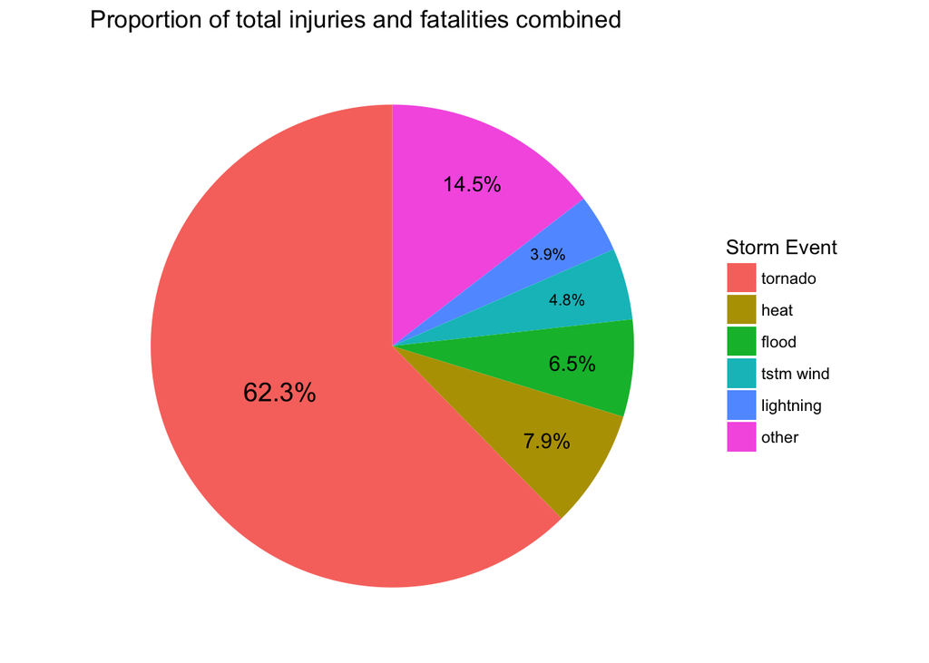

**Figure:** *The share of combined injuries and fatalities for each of the most dangerous storm event types based on the total morbidity and mortality recorded.*

```r
## Reformat data from combined injuries and fatalities to
## compress all events except for the top 5 into an "other"
## category
health_plot_data <- most_injuries_fatalities %>%
  mutate(category = ifelse(event_type %in% event_type[1:5], levels(event_type)[event_type], "other"))

health_plot_data$category <- factor(health_plot_data$category)

## Calculate percentage of all combined injuries and fatalities for each category
all_injuries_fatalities <- sum(health_plot_data$total_injuries_fatalities)
health_plot_data <- health_plot_data %>%
  group_by(category) %>%
  summarize(proportion = sum(total_injuries_fatalities)/all_injuries_fatalities) %>%
  arrange(desc(proportion))

## Rearrange category levels in descending order by proportion and
## then place "other" category at the end of the factor levels for the
## category label so it gets plotted last
cat_labels_order <- as.character(health_plot_data$category)
cat_levels <- c(cat_labels_order[-which(cat_labels_order=="other")], "other")
health_plot_data$category <- factor(health_plot_data$category, levels = cat_levels)

## Move "other" category to the last row of health_plot_data (to match order of levels now)
indx <- as.character(health_plot_data$category) %in% c("other")
health_plot_data <- rbind(health_plot_data[!indx,], health_plot_data[indx,])

## Define blank theme for pie chart
blank_theme <- theme_minimal()+
  theme(
  axis.title.x = element_blank(),
  axis.title.y = element_blank(),
  panel.border = element_blank(),
  panel.grid=element_blank(),
  axis.ticks = element_blank(),
  axis.text.x=element_blank()
  )

## Create pie chart
pie <- ggplot(data = health_plot_data,
            mapping = aes(x = "", y = proportion, fill = category)) +
  geom_col(width = 1) +
  blank_theme +
  geom_text(aes(x = c(rep(1.25, 5), 1),
                y = cumsum(rev(proportion)) - rev(proportion)/2,
                label = rev(percent(proportion))),
            size=c(4, rep(3,2), rep(4,2), 5)) +
  labs(x = "",
       title = "Proportion of total injuries and fatalities combined",
       fill = "Storm Event") +
  coord_polar("y", start=0) + # convert col to pie
  NULL

print(pie)
```

From this plot, we see clearly that **tornadoes** contribute overwhelmingly to the combined number of injuries and fatalities from storm events in the US, based on these data.

## Economic impact

To asses which types of storm events have the greatest economic consequences, we can use the property and crop damage estimates (in dollars) from the NOAA database. These values are (supposed to be)[^1] stored as three significant digits followed by a suffix: “K” for thousand, “M” for million, and “B” for billion. The events with the greatest economic impact will result in the largest property and/or crop damage estimates. Again, we display the top five most damaging event types in each category.

### Top 5 events leading to the most property damage

```r
## Calculate the sum of all property damage for each event type
most_propdmg <- data %>%
  filter(propdmgexp %in% c("B", "M", "K")) %>%
  mutate(propdmg_full = ifelse(propdmgexp == "B", propdmg*1e9,
                               ifelse(propdmgexp == "M", propdmg*1e6,
                                      ifelse(propdmgexp =="K", propdmg*1e3, NA)))) %>%
  group_by(event_type) %>%
  summarise(total_propdmg = sum(propdmg_full)) %>%
  arrange(desc(total_propdmg))

## Print the top 5
print(head(most_propdmg, n=5))
```

```
## # A tibble: 5 x 2
##   event_type          total_propdmg
##   <fct>                       <dbl>
## 1 flood               167529740320.
## 2 hurricane (typhoon)  85256410010.
## 3 tornado              56993097730.
## 4 storm surge          43323536000.
## 5 hail                 17619990720.
```

### Top 5 events leading to the most crop damage

```r
## Calculate the sum of all property damage for each event type
most_cropdmg <- data %>%
  filter(cropdmgexp %in% c("B", "M", "K")) %>%
  mutate(cropdmg_full = ifelse(cropdmgexp == "B", cropdmg*1e9,
                               ifelse(cropdmgexp == "M", cropdmg*1e6,
                                      ifelse(cropdmgexp =="K", cropdmg*1e3, NA)))) %>%
  group_by(event_type) %>%
  summarise(total_cropdmg = sum(cropdmg_full)) %>%
  arrange(desc(total_cropdmg))

## Print the top 5
print(head(most_cropdmg, n=5))
```

```
## # A tibble: 5 x 2
##   event_type          total_cropdmg
##   <fct>                       <dbl>
## 1 drought              13972621780.
## 2 flood                12380109100.
## 3 hurricane (typhoon)   5506117800.
## 4 ice storm             5022113500.
## 5 hail                  3114212850.
```

### Top 5 events leading to the most combined property and crop damage

```r
## Calculate the sum of all crop damage for each event type
most_propcropdmg <- data %>%
  filter(propdmgexp %in% c("B", "M", "K")) %>%
  mutate(propdmg_full = ifelse(propdmgexp == "B", propdmg*1e9,
                               ifelse(propdmgexp == "M", propdmg*1e6,
                                      ifelse(propdmgexp =="K", propdmg*1e3, NA)))) %>%
  filter(cropdmgexp %in% c("B", "M", "K")) %>%
  mutate(cropdmg_full = ifelse(cropdmgexp == "B", cropdmg*1e9,
                               ifelse(cropdmgexp == "M", cropdmg*1e6,
                                      ifelse(cropdmgexp =="K", cropdmg*1e3, NA)))) %>%
  group_by(event_type) %>%
  summarise(total_propcropdmg = sum(propdmg_full + cropdmg_full)) %>%
  arrange(desc(total_propcropdmg))

## Print the top 5
print(head(most_propcropdmg, n=5))
```

```
## # A tibble: 5 x 2
##   event_type          total_propcropdmg
##   <fct>                           <dbl>
## 1 flood                   157763450740.
## 2 hurricane (typhoon)      44220000800.
## 3 tornado                  16520165650.
## 4 hail                     11653045140.
## 5 ice storm                 5925147300.
```

Based on the above results, **floods** are the most harmful with respect to property damage, as well as property and crop damage combined, while **droughts** are the most harmful with respect to crop damage.

To understand the share of each event type relative to all recorded property and crop damage amounts, we plot a pie chart of the top five most damaging events, compressing all other events into an “other” category.

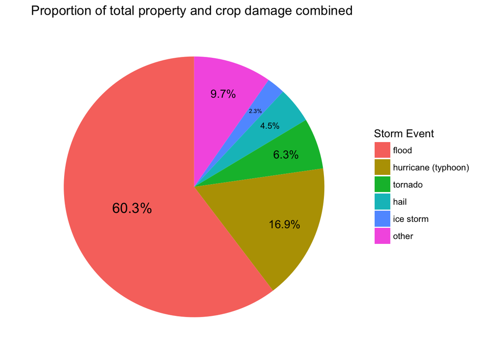

**Figure:** *The share of combined property and crop damage amounts for each of the most damaging storm event types based on the total economic costs recorded.*

```r
## Reformat data from combined property and crop damage amounts to
## compress all events except for the top 5 into an "other"
## category
econ_plot_data <- most_propcropdmg %>%
  mutate(category = ifelse(event_type %in% event_type[1:5], levels(event_type)[event_type], "other"))

econ_plot_data$category <- factor(econ_plot_data$category)

## Calculate percentage of all combined property and crop damage
## values for each category
all_propcropdmg <- sum(econ_plot_data$total_propcropdmg)
econ_plot_data <- econ_plot_data %>%
  group_by(category) %>%
  summarize(proportion = sum(total_propcropdmg)/all_propcropdmg) %>%
  arrange(desc(proportion))

## Rearrange category levels in descending order by proportion and
## then place "other" category at the end of the factor levels for the
## category label so it gets plotted last
cat_labels_order <- as.character(econ_plot_data$category)
cat_levels <- c(cat_labels_order[-which(cat_labels_order=="other")], "other")
econ_plot_data$category <- factor(econ_plot_data$category, levels = cat_levels)

## Move "other" category to the last row of econ_plot_data (to match order of levels now)
indx <- as.character(econ_plot_data$category) %in% c("other")
econ_plot_data <- rbind(econ_plot_data[!indx,], econ_plot_data[indx,])

## Create pie chart
pie <- ggplot(data = econ_plot_data,
            mapping = aes(x = "", y = proportion, fill = category)) +
  geom_col(width = 1) +
  blank_theme +
  geom_text(aes(x = c(rep(1.25, 5), 1),
                y = cumsum(rev(proportion)) - rev(proportion)/2,
                label = rev(percent(proportion))),
            size=c(4, 2, 3, rep(4,2), 5)) +
  labs(x = "",
       title = "Proportion of total property and crop damage combined",
       fill = "Storm Event") +
  coord_polar("y", start=0) + # convert col to pie
  NULL

print(pie)
```

# Conclusion

The above analysis indicates that on the whole, **tornadoes** are the most harmful to population health, while **floods** and **droughts** are the most economically costly with respect to property and crop damage, respectively.

# Future work

## Data processing

The way in which we resolved data entry inconsistencies (by consulting the official storm data event table and using it to replace duplicate labels) does not allow for categories that share words to remain distinct (e.g. observations from “cold/wind chill” and “extreme cold/wind chill” become part of the same category); a more sophisticated find-and-replace scheme should be used if one wishes to keep these types of categories distinct.

There are also spelling errors in the event types that need to be resolved to ensure that all of the observations are correctly classified.

## Analysis

Some storm events occur more frequently than others, so we may want to normalize outcome measures by the event frequency as a different way to gauge the degree to which each event type is dangerous or economically costly.

It may also be illuminating to perform a time series analysis of the effects of different storm events on population health and the economy, in case patterns have changed recently.

Lastly, it may be also be beneficial to break the above analysis down by state to infer the the most dangerous and costly events within each state.

[^1]: There are data entry errors here as well, with some suffixes mysteriously entered as numeric values and punctuation. These are not included in our results as it is impossible to tell what the intended suffix was at data entry.